# Graphical Markov Models with Mixed Graphs in R

Kayvan Sadeghi

Department of Statistics, University of Oxford

Giovanni M. Marchetti

Dipartimento di Statistica “G. Parenti”, University of Florence

2012-12-01

Abstract

In this paper we provide a short tutorial illustrating the new functions in the package *ggm* that deal with ancestral, summary and ribbonless graphs. These are mixed graphs (containing three types of edges) that are important because they capture the modified independence structure after marginalisation over, and conditioning on, nodes of directed acyclic graphs. We provide functions to verify whether a mixed graph implies that $A$ is independent of $B$ given $C$ for any disjoint sets of nodes and to generate maximal graphs inducing the same independence structure of non-maximal graphs. Finally, we provide functions to decide on the Markov equivalence of two graphs with the same node set but different types of edges.

# Introduction and background

*Graphical Markov models* have become a part of the mainstream of statistical theory and application in recent years. These models use graphs to represent conditional independencies among sets of random variables. Nodes of the graph correspond to random variables and edges to some type of conditional dependency.

## Directed acyclic graphs

In the literature on graphical models the two most used classes of graphs are directed acyclic graphs (DAGs) and undirected graphs. DAGs have proven useful, among other things, to specify the data generating processes when the variables satisfy an underlying partial ordering.

For instance, suppose that we have four observed variables: $Y$, the ratio of systolic to diastolic blood pressure and $X$ the diastolic blood pressure, both on a log scale; $Z$, the body mass and $W$, the age, and that a possible generating process is the following linear recursive regression model
$$\begin{aligned}
Y &= \gamma_{YZ} Z + \gamma_{YU} U + \epsilon_Y\\
X &= \gamma_{XW} W + \gamma_{XU} U + \epsilon_X\\
Z &= \gamma_{ZV} W + \epsilon_Z\\
W &= \epsilon_W; \; U = \epsilon_U,
\end{aligned}$$
where all the variables are mean-centered and the $\epsilon$s are zero mean, mutually independent Gaussian random errors. In this model we assume that there exists a genetic factor $U$ influencing the ratio and levels of blood pressure.

This model can be represented by the DAG in Figure 1(a) with nodes associated with the variables and edges indicating the dependencies represented by the regression coefficients ($\gamma$s).

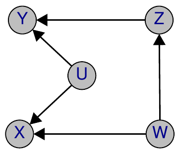

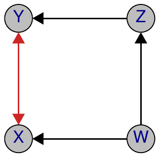

Figure 1: (a) A DAG. (b) A regression chain graph.

From the graph it is seen, for instance, that the ratio of the two blood pressures ($Y$) is directly influenced by body mass ($Z$) but not by age ($W$). Thus a consequence of the model is that the variables must satisfy a set of conditional independencies: for example, the ratio of the blood pressure is independent of the age given the body mass, written as $Y \perp \perp W | Z$.

A remarkable result is that the independencies can be deduced from the graph alone, without reference to the equations, by using a criterion called $d$-separation. In fact, in the graph of Figure 1(a), the nodes $Y$ and $W$ are $d$-separated given $Z$. This can be checked using special graph algorithms included, for example, in packages [*gRain*](https://CRAN.R-project.org/package=gRain) (Højsgaard 2012) and [*ggm*](https://CRAN.R-project.org/package=ggm) (Marchetti, M. Drton, and K. Sadeghi 2012). For more details on DAG models and their implementation in R see the extensive discussion in Højsgaard, D. Edwards, and S. Lauritzen (2012).

## Hidden variables and induced graphs

The model has four observed variables but includes an unobserved variable, that is, the genetic factor $U$. When $U$ is hidden the model for the observed variables becomes
$$\begin{aligned}
Y &= \gamma_{YZ} Z + \eta_Y \\
X &= \gamma_{XW} W + \eta_X \\
Z &= \gamma_{ZV} W + \epsilon_Z\\
W &= \epsilon_W;
\end{aligned}$$
with two correlated errors $\eta_{Y} = \gamma_{YU} U + \epsilon_Y$ and $\eta_X = \gamma_{XU} U + \epsilon_X$, such that $\mathrm{cov}(\eta_Y, \eta_X) = \omega_{YX}$. As a consequence the model is still a recursive model and the parameters have a regression parameter interpretation, but contain some correlated residuals.

The induced model is said to be obtained after marginalisation over $U$. In this model some of the original independencies are lost, but we can observe the implied independencies $Y \perp \perp W|Z$ and $X \perp \perp Z | W$. Also it can be shown that it is impossible to represent such independencies in a DAG model defined for the four observed variables. Therefore, we say that DAG models are not stable under marginalisation.

A mixed graph with arrows and arcs, as shown in Figure 1(b), can be used to represent the induced independence model after marginalisation over $U$. In this representation, beside the arrows, represented by the $\gamma$s, we have the arc $Y \prec \!\!\!\!\!\frac{}{} \!\!\!\!\! \succ\! X$ associated with the (partial) correlation $\omega_{YX}$.

The graph of Figure 1(b) belongs to a class of models called regression chain graph models. This class generalises the recursive generating process of DAGs by permitting joint responses, coupled in the graph by arcs, and thus appears to be an essential extension for applications; see Cox and N. Wermuth (1996). Regression chain graphs can be used as a conceptual framework for understanding multivariate dependencies, for example in longitudinal studies. The variables are arranged in a sequence of blocks, such that (a) all variables in one block are of equal standing and any dependence between them is represented by an arc, and (b) all variables in one block are responses to variables in all blocks to their right, so that any dependencies between them are directed, represented by an arrow pointing from right to left. The graph shows how the data analysis can be broken down into a series of regressions and informs about which variables should or should not be controlled for in each regression.

## More general induced graphs

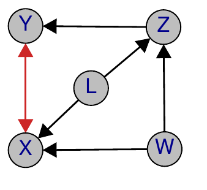

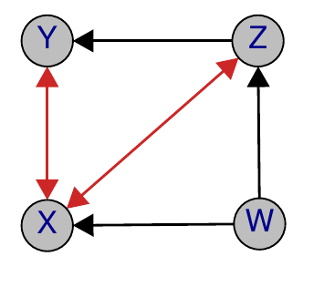

Figure 2: (a) A regression chain graph model; (b) the mixed graph obtained after marginalisation over L, which is not a regression chain graph.

## Stable mixed graphs

The previous illustrations show that when there are unobserved variables, DAG or regression chain graph models are no longer appropriate. The discussion could be extended to situations where there are some selection variables that are hidden variables that are conditioned on.

This motivates the introduction of a more general class of mixed graphs, which contains three types of edges, denoted by lines, $\, \frac{\;}{}$, arrows, $\frac{ }{ }\!\!\!\!\! \succ \!$, and arcs (bi-directed arrows), $\prec \!\!\!\!\!\frac{}{} \!\!\!\!\! \succ\!$. In the case of regression models, explained above, lines generally link pairs of joint context (explanatory) variables and arcs generally link pairs of joint response variables.

There are at least three known classes of mixed graphs without self loops that remain in the same class, i.e. that are stable under marginalisation and conditioning. The largest one is that of ribbonless graphs (RGs) (Sadeghi 2012b), defined as a modification of MC-graphs (Koster 2002). Then, there is the subclass of summary graphs (SGs) (Wermuth 2011), and finally the smallest class of the ancestral graphs (AGs) (Richardson and P. Spirtes 2002).

## Four tasks of the current paper

In this paper, we focus on the implementation of four important tasks performed on the class of mixed graphs in R:

1. Generating different types of stable mixed graphs after marginalisation and conditioning.
2. Verifying whether an independency of the form $Y \perp \perp W|Z$ holds by using a separation criterion called $m$-separation.
3. Generating a graph that induces the same independence structure as an input mixed graph such that the generated graph is maximal, i.e. each missing edge of the generated graph implies at least an independence statement.
4. Verifying whether two graphs are Markov equivalent, i.e. they induce the same independencies, and whether, given a graph of a specific type, there is a graph of a different type that is Markov equivalent to it.

## Package *ggm*

The tasks above are illustrated by using a set of new functions introduced into the R package [*ggm*](https://CRAN.R-project.org/package=ggm) (Marchetti, M. Drton, and K. Sadeghi 2012). In the next section we give the details of how general mixed graphs are defined. The following four sections deal with the four tasks respectively. For each task we give a brief introduction at the beginning of its corresponding section.

Some of the functions generalise previous contributions of *ggm* discussed in Marchetti (2006). The *ggm* package has been improved and it is now more integrated with other contributed packages related to graph theory, such as *graph* (Gentleman, E. Whalen, W. Huber, and S. Falcon 2012), [*igraph*](https://CRAN.R-project.org/package=igraph) (Csardi and T. Nepusz 2006), and [*gRbase*](https://CRAN.R-project.org/package=gRbase) (Dethlefsen and S. Højsgaard 2005), which are now required for representing and plotting graphs. Specifically, in addition to adjacency matrices, all the functions in the package now accept `graphNEL` and `igraph` objects as input, as well as a new character string representation. A more detailed list of available packages for graphical models can be found at the CRAN Task View *gRaphical Models in R* at http://cran.r-project.org/web/views/gR.html.